# Ketone Tolerance in Muscle Tsc1 Mice

Detrick Snyder, Cody Cousineau, JeAnna Redd, and Dave Bridges

August 8, 2019

This script was most recently run on Fri Aug 4 10:11:21 2023 and can be found in /Users/davebrid/Documents/GitHub/TissueSpecificTscKnockouts/Mouse Data/Muscle Tsc1 Knockout/Ketone Tolerance.

# Experimental Details

Beta hydroxybutyrate was injected at 1g/kg into fed mice around 14:00 PM, ketone levels were assessed via tail vein injection using strips.

# Raw Data

```r
raw_data_file <- "Muscle TSC Ketone Tolerance Data.csv"


library(readr)
measurement.data <- read_csv(raw_data_file)

library(lubridate)
measurement.data$parsed.experiment.date <- ymd(measurement.data$experiment.date)

genotype.problems <- c() #animals where we are unsure about the genotype/treatment

ketone.data <-
  filter(measurement.data, assay=='Ketone Bodies') %>%
  separate(values, sep=',', into=paste0("t",seq(0,120, by=15))) %>%
  select(age,Genotype,t0:t120,Genotype,animal.id,MouseID,Sex) %>%
  mutate(ITT = if_else(is.na(t15), "No","Yes")) %>%
  mutate(FK = as.numeric(t0)/10) %>%
  mutate_at(.vars=3:11, .funs=funs(as.numeric(.)/10)) %>%
  mutate(Genotype.ko = case_when(Genotype=='fl/fl; Tg/+'~"Muscle Tsc1 Knockout",
                                 TRUE~"Wild-Type")) %>%
  mutate(Genotype.ko = relevel(as.factor(Genotype.ko), ref="Wild-Type"))

ketone.data <-
  ketone.data %>%
  mutate(AUC = rowSums(ketone.data[3:7]))

ketone.data.norm <-
  ketone.data %>%
  filter(ITT=="Yes") %>%
  filter(!(MouseID %in% genotype.problems)) %>% #removed animals with incorrect genotype
  mutate(t15=t15/t0*100,
         t30=t30/t0*100,
         t45=t45/t0*100,
         t60=t60/t0*100,
         t75=t75/t0*100,
         t90=t90/t0*100,
         t105=t105/t0*100,
         t120=t120/t0*100,
         t0=t0/t0*100)



kable(ketone.data %>%
        filter(ITT=="Yes") %>%
        select(MouseID, Genotype, Sex, FK) %>%
        arrange(MouseID, Genotype),caption="Animals who underwent an KTT")
```

Animals who underwent an KTT

| MouseID | Genotype | Sex | FK |
| --- | --- | --- | --- |
| 8609 | fl/fl; Tg/+ | M | 0.3 |
| 8610 | fl/fl; +/+ | F | 0.3 |
| 8611 | fl/fl; +/+ | F | 0.5 |
| 8612 | fl/fl; Tg/+ | F | 0.6 |
| 8613 | fl/fl; +/+ | F | 0.4 |
| 8614 | fl/fl; Tg/+ | F | 0.3 |
| 8943 | fl/fl; Tg/+ | M | 0.3 |
| 8944 | fl/fl; Tg/+ | M | 0.4 |
| 8945 | fl/fl; Tg/+ | M | 0.4 |
| 8946 | fl/fl; Tg/+ | M | 0.4 |
| 8947 | fl/fl; Tg/+ | M | 0.3 |
| 8948 | fl/fl; Tg/+ | F | 0.4 |
| 8949 | fl/fl; Tg/+ | F | 0.6 |
| 8950 | fl/fl; Tg/+ | F | 0.6 |
| 8951 | fl/fl; +/+ | F | 0.7 |
| 9235 | fl/fl; Tg/+ | M | 0.7 |
| 9238 | fl/fl; +/+ | M | 0.5 |
| 9239 | fl/fl; +/+ | M | 0.5 |
| 9240 | fl/fl; Tg/+ | M | 0.6 |
| 9241 | fl/fl; +/+ | M | 0.4 |
| 9309 | fl/fl; Tg/+ | M | 0.4 |
| 9314 | fl/fl; Tg/+ | M | 0.7 |
| 9315 | fl/fl; +/+ | M | 0.4 |

```r
ketone.data %>%
  filter(ITT=="Yes") %>%
  group_by(Genotype,Sex) %>%
  count %>%
  kable(caption="Animals evaluated by KTT in each group")
```

Animals evaluated by KTT in each group

| Genotype | Sex | n |
| --- | --- | --- |
| fl/fl; +/+ | F | 4 |
| fl/fl; +/+ | M | 4 |
| fl/fl; Tg/+ | F | 5 |
| fl/fl; Tg/+ | M | 10 |

# Analysis

```r
ketone.summary <-
  ketone.data %>%
  group_by(Genotype.ko, Sex) %>%
  summarize(FK.mean = mean(FK, na.rm=T),
            FK.se = se(FK),
            FK.sd = sd(FK,na.rm=T),
            N = length(FK))

kable(ketone.summary, caption="Summary statistics for analysis of fasting ketone levels")
```

Summary statistics for analysis of fasting ketone levels

| Genotype.ko | Sex | FK.mean | FK.se | FK.sd | N |
| --- | --- | --- | --- | --- | --- |
| Wild-Type | F | 0.475 | 0.085 | 0.171 | 4 |
| Wild-Type | M | 0.450 | 0.029 | 0.058 | 4 |
| Muscle Tsc1 Knockout | F | 0.500 | 0.063 | 0.141 | 5 |
| Muscle Tsc1 Knockout | M | 0.450 | 0.050 | 0.158 | 10 |

```r
ketone.summary.auc <-
  ketone.data %>%
  group_by(Genotype.ko, Sex) %>%
  summarize(AUC.mean = mean(AUC, na.rm=T),
            AUC.se = se(AUC),
            AUC.sd = sd(AUC,na.rm=T),
            N = length(AUC))

kable(ketone.summary.auc, caption="Summary statistics for analysis of ketone levels (area under the curve)")
```

Summary statistics for analysis of ketone levels (area under the curve)

| Genotype.ko | Sex | AUC.mean | AUC.se | AUC.sd | N |
| --- | --- | --- | --- | --- | --- |
| Wild-Type | F | 4.83 | 0.506 | 1.012 | 4 |
| Wild-Type | M | 6.33 | 0.368 | 0.737 | 4 |
| Muscle Tsc1 Knockout | F | 4.33 | 0.257 | 0.574 | 5 |
| Muscle Tsc1 Knockout | M | 4.48 | 0.401 | 1.269 | 10 |

## Fed Ketone Levels

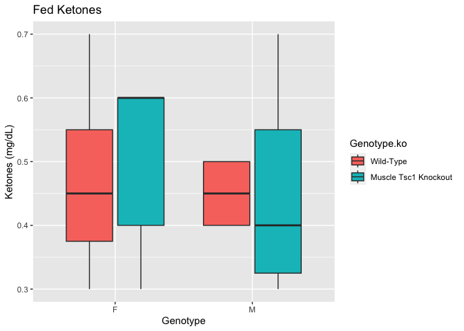

Fed ketones, by treatment

```r
library(ggplot2)
ggplot(filter(ketone.data, ITT=="Yes"),
            aes(y=FK, x=Sex, fill=Genotype.ko)) +
  geom_boxplot() +
  labs(title="Fed Ketones",
       y="Ketones (mg/dL)",
       x="Genotype")
```

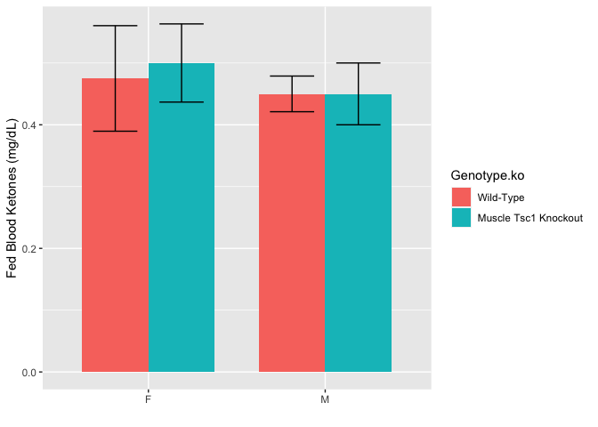

Fed ketones

```r
ggplot(ketone.summary,
       aes(y=FK.mean,
           ymin = FK.mean - FK.se,
           ymax = FK.mean + FK.se,
           x = Sex,
           fill= Genotype.ko)) +
  geom_bar(stat='identity', position='dodge', width=0.75) +
  geom_errorbar(position=position_dodge(width=0.75), width=0.5) +
  labs(y='Fed Blood Ketones (mg/dL)',
       x='')
```

### Fasting ketone Statistics

```r
library(broom)
fk.aov <- aov(FK~Sex+Genotype, data=ketone.data)
tidy(fk.aov) %>% kable(caption="ANOVA for effects of fasting ketone")
```

ANOVA for effects of fasting ketone

| term | df | sumsq | meansq | statistic | p.value |
| --- | --- | --- | --- | --- | --- |
| Sex | 1 | 0.008 | 0.008 | 0.411 | 0.529 |
| Genotype | 1 | 0.001 | 0.001 | 0.030 | 0.864 |
| Residuals | 20 | 0.403 | 0.020 | NA | NA |

## Ketone Tolerance Test

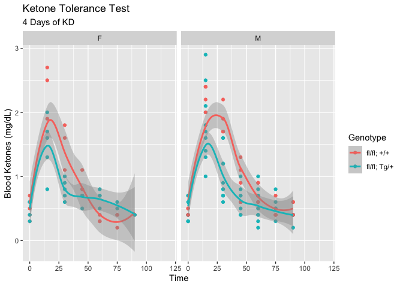

Ketone tolerance tests by treatments

```r
time <- seq(0,120,by=15)
ktt.data.long <-
  ketone.data %>%
  filter(ITT=="Yes") %>%
  select(-age) %>%
  group_by(Genotype, Sex,animal.id) %>%
  gather(`t0`:`t120`,key='TimeStamp', value="ketone") %>%
  separate(TimeStamp, sep="t", into=c("Letter","Time")) %>%
  mutate(ketone = as.numeric(ketone)) %>%
  mutate(Time = as.numeric(Time))

ktt.data.long.norm <-
  ketone.data.norm %>%
  filter(ITT=="Yes") %>%
  select(-age) %>%
  group_by(animal.id,Genotype, Sex) %>%
  gather(`t0`:`t120`,key='TimeStamp', value="ketone") %>%
  separate(TimeStamp, sep="t", into=c("Letter","Time")) %>%
  mutate(ketone = as.numeric(ketone)) %>%
  mutate(Time = as.numeric(Time))

ggplot(ktt.data.long,
            aes(y=ketone, x=Time, col=Genotype)) +
  geom_point() +
  facet_grid(.~Sex) +
  geom_smooth(method="loess") +
  labs(title="Ketone Tolerance Test",
       subtitle="4 Days of KD",
       y="Blood Ketones (mg/dL)")
```

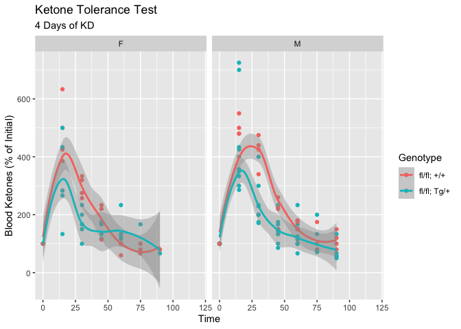

Ketone tolerance tests by treatments

```r
ggplot(ktt.data.long.norm,
            aes(y=ketone, x=Time, col=Genotype)) +
  geom_point() +
    facet_grid(.~Sex) +
  geom_smooth(method="loess") +
  labs(title="Ketone Tolerance Test",
       subtitle="4 Days of KD",
       y="Blood Ketones (% of Initial)")
```

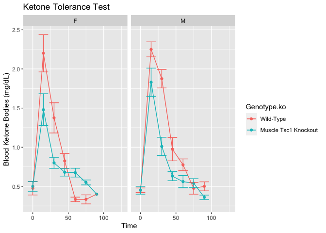

```r
ktt.data.long %>%
  group_by(Time,Genotype.ko, Sex) %>%
  summarize(Average = mean(ketone, na.rm=T),
            Error = se(ketone)) %>%
ggplot(aes(y=Average,
           ymax=Average+Error,
           ymin=Average-Error,
           x=Time, col=Genotype.ko)) +
  geom_point() +
  geom_line() +
  facet_grid(.~Sex) +
  geom_errorbar() +
  labs(title="Ketone Tolerance Test",
       y="Blood Ketone Bodies (mg/dL)")
```

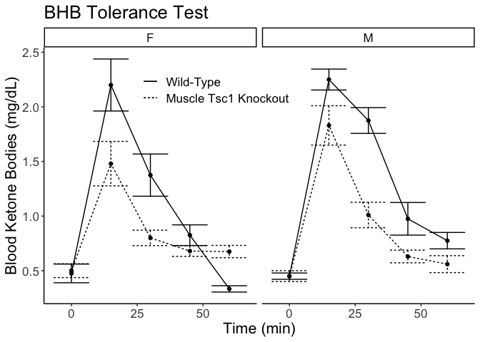

```r
ktt.data.long %>%
  filter(Time<=60) %>%
  group_by(Time,Genotype.ko, Sex) %>%
  summarize(Average = mean(ketone, na.rm=T),
            Error = se(ketone)) %>%
ggplot(aes(y=Average,
           ymax=Average+Error,
           ymin=Average-Error,
           x=Time, lty=Genotype.ko)) +
  geom_point() +
  geom_line() +
  facet_grid(.~Sex) +
  geom_errorbar() +
  labs(title="BHB Tolerance Test",
       y="Blood Ketone Bodies (mg/dL)",
       x="Time (min)") +
  theme_classic() +
  theme(text=element_text(size=16),
        legend.position=c(0.4,0.85),
        legend.title=element_blank())
```

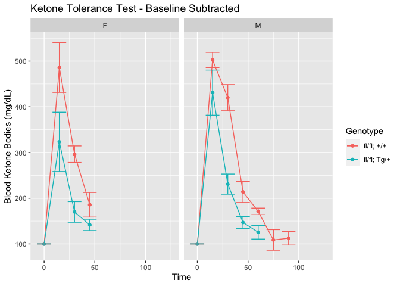

```r
ktt.data.long.norm %>%
  group_by(Time,Genotype,Sex) %>%
  summarize(Average = mean(ketone),
            Error = se(ketone)) %>%
ggplot(aes(y=Average,
           ymax=Average+Error,
           ymin=Average-Error,
           x=Time, col=Genotype)) +
  facet_grid(.~Sex) +
  geom_point() +
  geom_line() +
  geom_errorbar() +
  labs(title="Ketone Tolerance Test - Baseline Subtracted",
       y="Blood Ketone Bodies (mg/dL)")
```

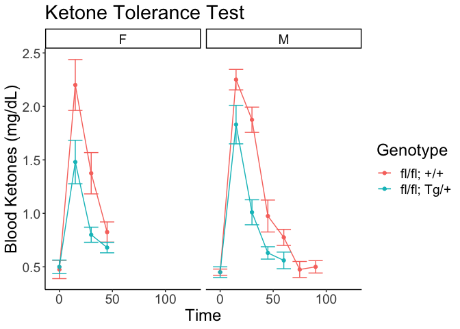

```r
ktt.data.long %>%
  group_by(Time,Genotype, Sex) %>%
  summarize(Average = mean(ketone),
            Error = se(ketone)) %>%
ggplot(aes(y=Average,
           ymax=Average+Error,
           ymin=Average-Error,
           x=Time, col=Genotype)) +
  geom_point() +
  geom_line() +
    facet_grid(.~Sex) +
  geom_errorbar() +
  labs(title="Ketone Tolerance Test",
       y="Blood Ketones (mg/dL)") +
  theme_classic() + # to get the overall layout
  theme(text = element_text(size=18)) # to increase font
```

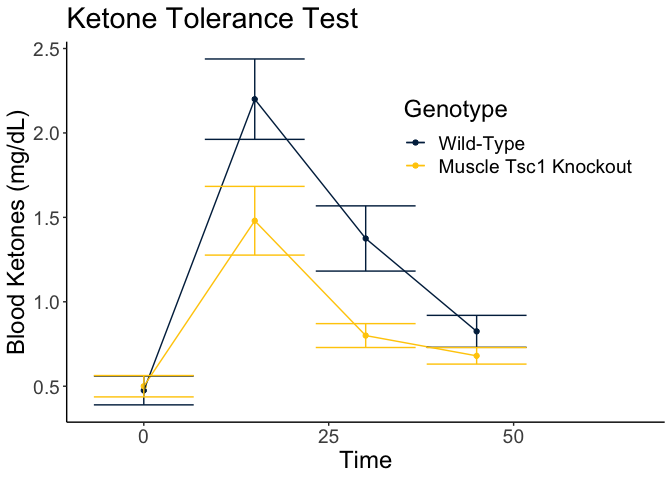

Ketone tolerance test of Tsc1 knockout females.

```r
ktt.data.long %>%
  filter(Sex=="F", Time<=60) %>%
  group_by(Time,Genotype) %>%
  summarize(Average = mean(ketone),
            Error = se(ketone)) %>%
ggplot(aes(y=Average,
           ymax=Average+Error,
           ymin=Average-Error,
           x=Time, col=Genotype)) +
  geom_point() +
  geom_line() +
  geom_errorbar() +
  labs(title="Ketone Tolerance Test",
       y="Blood Ketones (mg/dL)") +
  scale_color_manual(values=color.scheme,
                     labels=c("Wild-Type","Muscle Tsc1 Knockout")) +
  theme_classic() +
  theme(legend.position=c(0.75,0.75),
        text=element_text(size=18))
```

### Calculated based on AUC

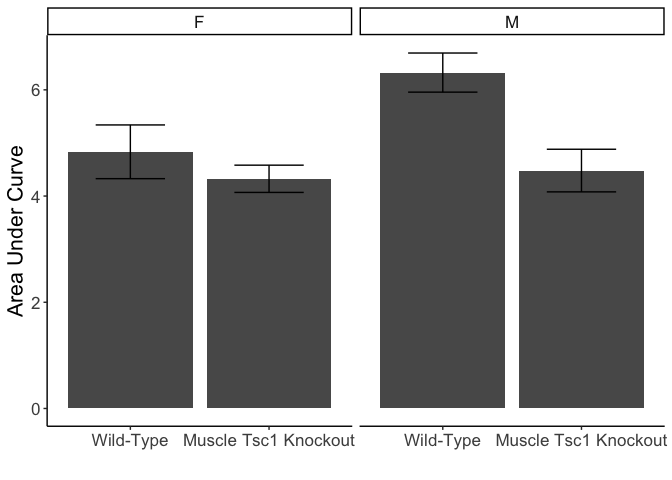

```r
ggplot(ketone.summary.auc,
       aes(y=AUC.mean,
           ymin=AUC.mean-AUC.se,
           ymax=AUC.mean+AUC.se,
           x=Genotype.ko)) +
  geom_bar(stat='identity') +
  geom_errorbar(width=0.5) +
  facet_grid(~Sex) +
  labs(y='Area Under Curve',
       x="") +
  theme_classic() +
  theme(text=element_text(size=16))
```

```r
lm(AUC~Sex+Genotype.ko,data=ketone.data) %>% tidy %>%
  kable(caption="2x2 ANOVA for sex and genotype for AUC")
```

2x2 ANOVA for sex and genotype for AUC

| term | estimate | std.error | statistic | p.value |
| --- | --- | --- | --- | --- |
| (Intercept) | 5.311 | 0.501 | 10.60 | 0.000 |
| SexM | 0.656 | 0.506 | 1.30 | 0.211 |
| Genotype.koMuscle Tsc1 Knockout | -1.344 | 0.506 | -2.65 | 0.016 |

```r
lm(AUC~Sex+Genotype.ko+Sex:Genotype.ko,data=ketone.data) %>% tidy %>%
  kable(caption="2x2 ANOVA for sex and genotype for AUC, including interaction")
```

2x2 ANOVA for sex and genotype for AUC, including interaction

| term | estimate | std.error | statistic | p.value |
| --- | --- | --- | --- | --- |
| (Intercept) | 4.833 | 0.613 | 7.886 | 0.000 |
| SexM | 1.492 | 0.811 | 1.840 | 0.083 |
| Genotype.koMuscle Tsc1 Knockout | -0.508 | 0.811 | -0.627 | 0.539 |
| SexM:Genotype.koMuscle Tsc1 Knockout | -1.337 | 1.026 | -1.303 | 0.210 |

## KTT Statistics

### Male Mixed Linear Models

```r
library(lme4)
library(lmerTest)
lme.geno <- lmer(ketone ~ as.factor(Time) + Genotype.ko + (1|animal.id), data= ktt.data.long %>%
       filter(Sex=="M"))
lme.null <- lmer(ketone ~ as.factor(Time) + (1|animal.id), data= ktt.data.long %>%
       filter(Sex=="M"))

anova(lme.geno, lme.null) %>% tidy %>% kable(caption="Comparason of mixed linear models with or without a genotype term for male mice only")
```

Comparason of mixed linear models with or without a genotype term for male mice only

| term | npar | AIC | BIC | logLik | deviance | statistic | df | p.value |
| --- | --- | --- | --- | --- | --- | --- | --- | --- |
| lme.null | 9 | 49.6 | 71.9 | -15.8 | 31.6 | NA | NA | NA |
| lme.geno | 10 | 44.9 | 69.7 | -12.5 | 24.9 | 6.64 | 1 | 0.01 |

```r
#anova(lme.geno) %>% tidy %>% kable(caption="Model terms for mixed linear model, male mice only")
fixef(lme.geno) %>% tidy %>% kable(caption="Effect sizes for mixed linear model, female mice only")
```

| names | x |
| --- | --- |
| (Intercept) | 0.680 |
| as.factor(Time)15 | 1.500 |
| as.factor(Time)30 | 0.807 |
| as.factor(Time)45 | 0.279 |
| as.factor(Time)60 | 0.171 |
| as.factor(Time)75 | -0.066 |
| as.factor(Time)90 | -0.155 |
| Genotype.koMuscle Tsc1 Knockout | -0.323 |

```r
ktt.summary.male <-
  ktt.data.long %>%
  filter(Sex=="M", Time<=60) %>%
  group_by(Time) %>%
  summarize(WT.KB = mean(ketone[Genotype=="fl/fl; +/+"],na.rm=T),
            KO.KB = mean(ketone[Genotype=="fl/fl; Tg/+"], na.rm=T),
            p.val = t.test(ketone~Genotype, var.equal=T)$p.value) %>%
  mutate(Pct.Difference = (WT.KB-KO.KB)/WT.KB*100)

ktt.summary.male %>%
  kable(caption="Student's t-tests at each time point, males only")
```

Student’s t-tests at each time point, males only

| Time | WT.KB | KO.KB | p.val | Pct.Difference |
| --- | --- | --- | --- | --- |
| 0 | 0.450 | 0.45 | 1.000 | 0.0 |
| 15 | 2.250 | 1.83 | 0.183 | 18.7 |
| 30 | 1.875 | 1.01 | 0.001 | 46.1 |
| 45 | 0.975 | 0.63 | 0.020 | 35.4 |
| 60 | 0.775 | 0.56 | 0.133 | 27.7 |

The male mice had lower ketone levels during the Ketone tolerance test (p=0.01). On average ketone levels were 33.395% lower in the male knockout mice.